# SERC Analysis

Christopher Boyer

January 21, 2015

## Background

Data for the evaluation of SERC come from routine monitoring and surveillance of emergency referral activity in three implementation districts (Bongo, Builsa North, and Builsa South) in rural Northern Ghana. Primary data are captured via an emergency referral form completed by health staff upon arrival at the receiving health facility. These forms are collected bi-weekly and entered into a shared database. Additional data concerning program expenditures and service utilization are aggregated by facility and collected on a monthly basis.

## Raw Data

```r
referrals <- read.table("./data/VTRF_Export-2015-06-22.txt", sep = ",", header = T)
```

Below are the 74 variables captured by the SERC monitoring system for each referral record.

```
##  [1] "GlobalRecordId"     "GHSReferralNo"      "Station"
##  [4] "DistrictName"       "FirstName"          "LastName"
##  [7] "StationNo"          "Age"                "Sex"
## [10] "IsPregnant"         "ReferralDate"       "MultiStage"
## [13] "Accompanied"        "PatientLoc"         "KMStart"
## [16] "KMEnd"              "Breakdown"          "NormalLabor"
## [19] "ComplicatedLabor"   "Abortion"           "Malaria"
## [22] "Anemia"             "ARI"                "MCEmergencyPhone"
## [25] "MCEmergencyRadio"   "MCOther"            "RTA"
## [28] "SnakeBite"          "MCPersonalPhone"    "MCInPerson"
## [31] "Poisoning"          "Meningitis"         "Hypertension"
## [34] "Injury"             "RequestTime"        "Diarrhea"
## [37] "Septicemia"         "DepartureTime"      "Dyspnea"
## [40] "OtherReason"        "OtherReasonTXT"     "PickUpTime"
## [43] "ArrivalTime"        "ReceivingFacility"  "District"
## [46] "Alerted"            "WasEmergency"       "SubDistrict"
## [49] "Outcome1"           "Outcome4"           "Outcome2"
## [52] "Outcome5"           "Community"          "Outcome3"
## [55] "Outcome6"           "Facility"           "Outcome7"
## [58] "OutcomeTXT"         "DepartureLatitude"  "DepartureLongitude"
## [61] "PickUpLatitude"     "PickUpLongitude"    "ArrivalLatitude"
## [64] "ArrivalLon"         "departureID"        "ArrivalLongitude"
## [67] "ArrivalLat"         "PickUpLon"          "PickUpLat"
## [70] "DepartureLon"       "DepartureLat"       "pickupID"
## [73] "referralID"         "arrivalID"
```

## Additional Variables

### 1. Delay

The delay corresponds to the time elapsed from the initial request for the ambulance until the departure of the vehicle from the station.

```r
referrals$Delay <- difftime(referrals$DepartureTime,referrals$RequestTime, units = "min")
```

### 2. Trip Duration

The trip duration is the time elapsed from the departure of the ambulance until arrival at the receiving health facility.

```r
referrals$Duration <- difftime(referrals$ArrivalTime, referrals$DepartureTime,units = "min")
```

### 3. Distance Traveled

The distance traversed by the ambulance from vehicle station to patient pick up point to receiving health facility, or, alternatively, from vehicle station straight to receiving health facility can be estimated using facility and community geocoordinates recorded in the SERC database. Great circle distances between departure, pickup, and arrival points are estimated using Vincenty’s formula for an oblate spheroid with WGS 1984 parameters.

```r
# referrals$ReferralDistance <- ifelse(referrals$PickUp == "",
#         # if no pick up location calculate distance from departure to arrival
#         distVincentyEllipsoid(cbind(referrals$ArrivalLon,referrals$ArrivalLat),
#                               cbind(referrals$DepartureLon,referrals$DepartureLat)),
#         # otherwise calculate distance from departure to pick up point to arrival
#         distVincentyEllipsoid(cbind(referrals$PickUpLon,referrals$PickUpLat),
#                               cbind(referrals$DepartureLon,referrals$DepartureLat)) +
#         distVincentyEllipsoid(cbind(referrals$ArrivalLon,referrals$ArrivalLat),
#                               cbind(referrals$PickUpLon,referrals$PickUpLat)))
# # unit conversion m -> km
# referrals$ReferralDistance <- referrals$ReferralDistance/1000
```

Emergency call outs within the same community (n = 0) are assigned a randomly sampled value between 0 and 1 to represent the short distances traveled in these situations.

```r
# assign 0.5 km to emergency call outs within same community
# ind.SameCom <- which((referrals$Departure == referrals$Arrival) & (referrals$ReferralDistance == 0))
# referrals$ReferralDistance[ind.SameCom] <- sample(seq(0,1,0.01),1,replace = F)
```

## Drop Variables

Several variables either have no records or are irrelevant to this analysis. These variables are dropped from the data set.

```r
# drop variables
referrals$DepartureTime <- NULL
referrals$DepartureLon <- NULL
referrals$DepartureLat <- NULL
referrals$PickUpTime <- NULL
referrals$PickUpLon <- NULL
referrals$PickUpLat <- NULL
referrals$ArrivalTime <- NULL
referrals$ArrivalLon <- NULL
referrals$ArrivalLat <- NULL
referrals$MultiStage <- NULL
referrals$OtherReasonTXT <- NULL
referrals$OutcomeTXT <- NULL
referrals$GHSReferralNo <- NULL

# strip time information from request time variable and apply same date for analysis purposes
referrals$RequestTime <- strftime(referrals$RequestTime, format=c("%H:%M:%S"))
referrals$RequestTime <- as.POSIXct(referrals$RequestTime, format=c("%H:%M:%S"))
```

## Univariate Analysis

### 1. Date-time Variables

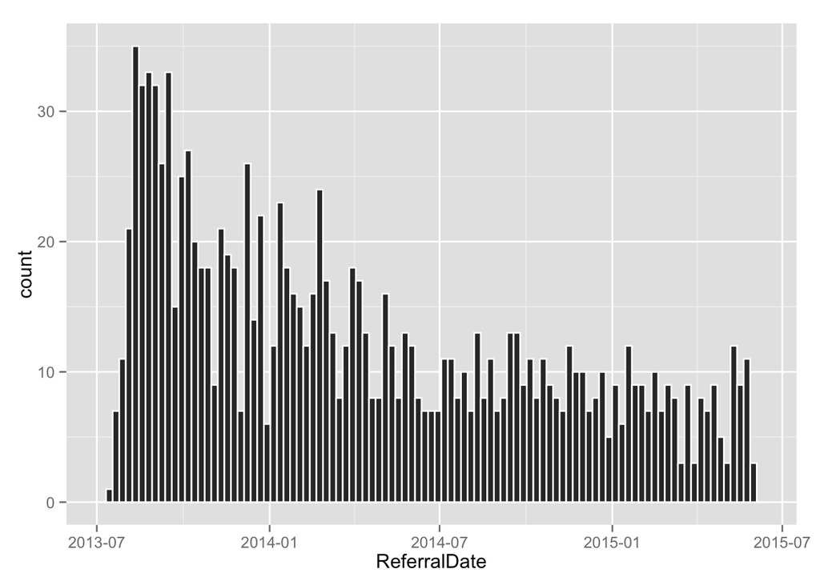

```r
# bin size (equivalent to 7 days)
bin <- 604800

# plot weekly tallies
ggplot(referrals, aes(x=ReferralDate)) + geom_histogram(colour=c("#FFFFFF"), binwidth=bin)
```

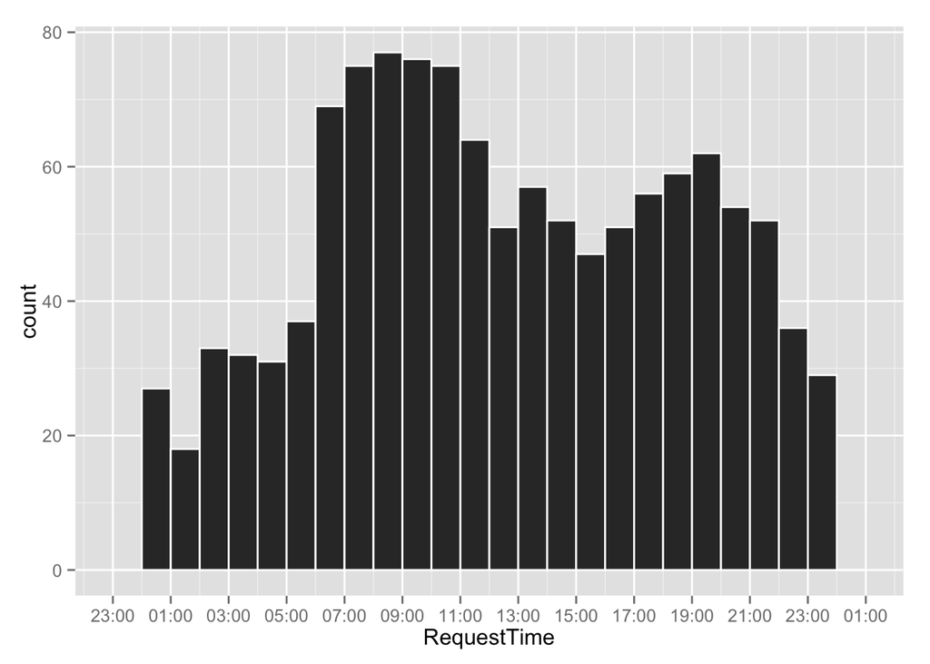

```r
# plot time of day histogram for requests
ggplot(referrals, aes(RequestTime)) +
  geom_histogram(binwidth = 3600, colour=c("#FFFFFF")) +
  scale_x_datetime(breaks = "2 hours", labels=date_format("%H:%M"))
```

```r
# monthly tallies
referrals$MonthDate <- format(referrals$ReferralDate, format = c("%Y-%m"))
by_month <- group_by(referrals, MonthDate)
by_month <- summarize(by_month, count=n(), percent=100*n()/dim(by_month)[1])
```

[output not shown]

### 2. Continuous Variables

```r
#contVars <- referrals %>% select(ID, Duration, Delay, ReferralDistance, Age, CatchementPop) %>% gather(key, value, -ID)

# plot delay and duration histograms
#ggplot(data=contVars, aes(x=value)) + geom_histogram() + facet_wrap( ~key, scales="free_x")
```

### 3. Categorical Variables

```r
catVars <- referrals %>% select(PatientLoc, Breakdown, Accompanied, Alerted, Sex, IsPregnant)  %>% gather(key, value)
```

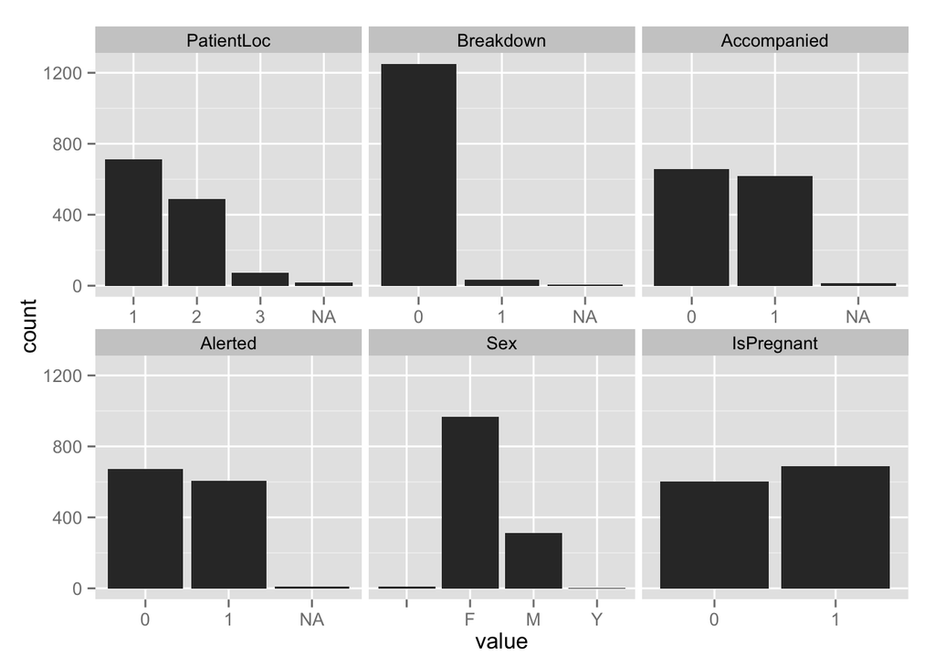

```r
ggplot(data=catVars, aes(x=value)) + geom_histogram() + facet_wrap( ~key, scales="free_x")
```

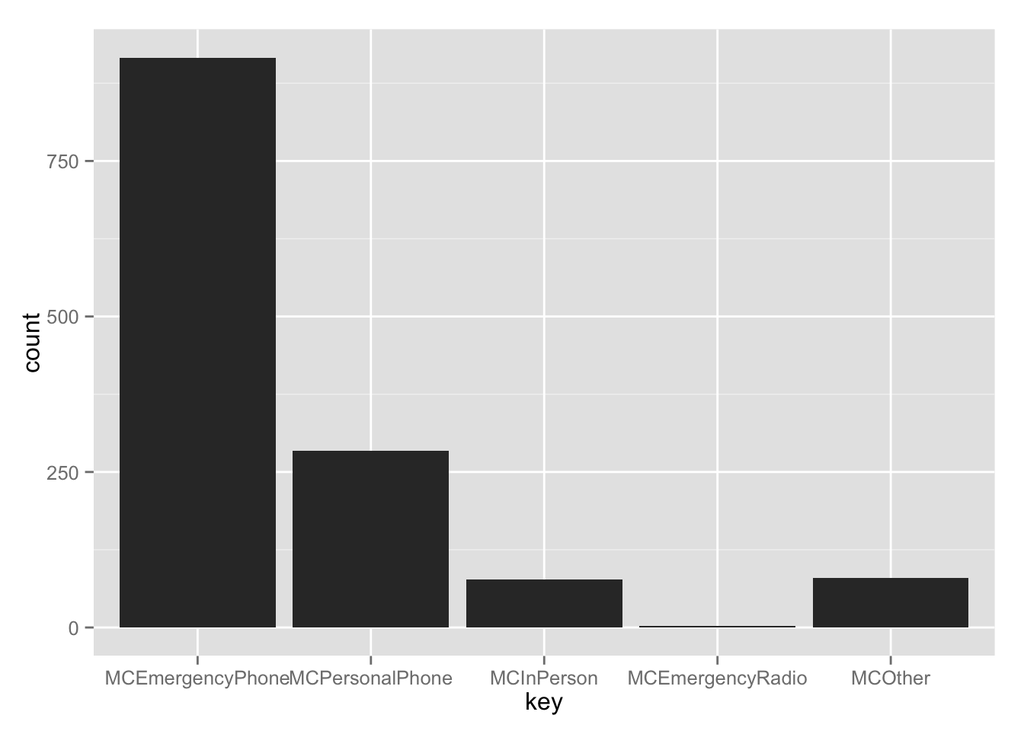

```r
Communication <- referrals %>% select(MCEmergencyPhone, MCPersonalPhone, MCInPerson, MCEmergencyRadio, MCOther) %>% gather(key, value) %>% filter(value==TRUE)

qplot(key, data=Communication, geom="bar")
```

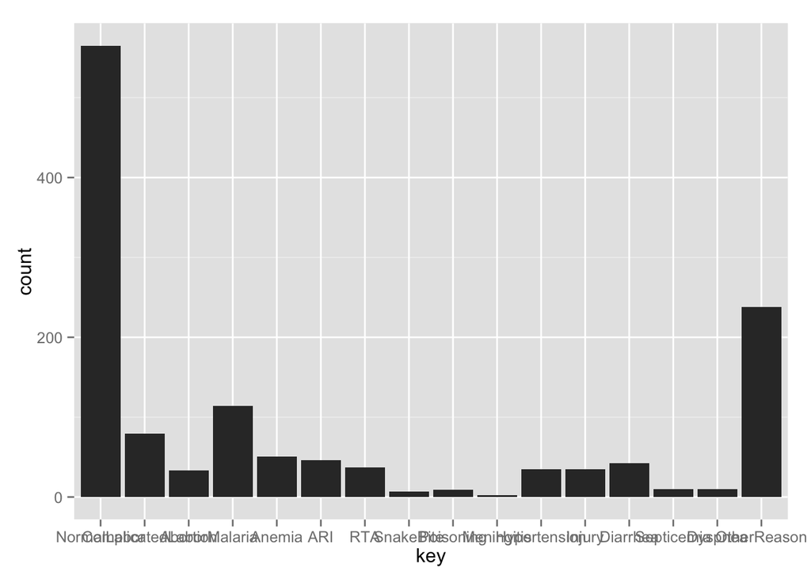

```r
Reason <- referrals %>% select(NormalLabor, ComplicatedLabor, Abortion, Malaria, Anemia, ARI, RTA, SnakeBite, Poisoning, Meningitis, Hypertension, Injury, Diarrhea, Septicemia, Dyspnea, OtherReason) %>% gather(key, value) %>% filter(value==TRUE)

qplot(key, data=Reason, geom="bar")
```

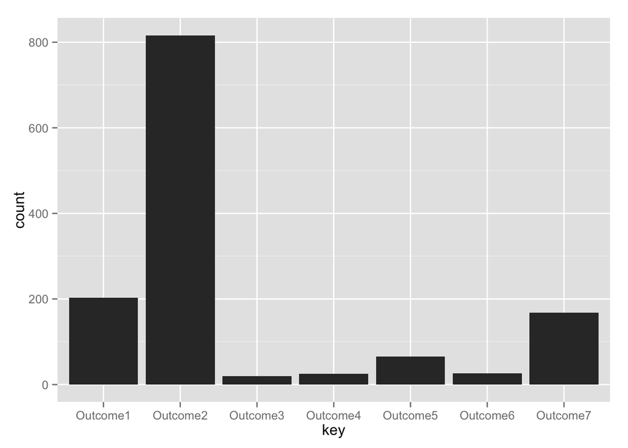

```r
Outcome <- referrals %>% select(Outcome1, Outcome2, Outcome3, Outcome4, Outcome5, Outcome6, Outcome7) %>% gather(key, value) %>% filter(value==TRUE)

qplot(key, data=Outcome, geom="bar")
```

## Bivariate

### 1. Patient Demographics

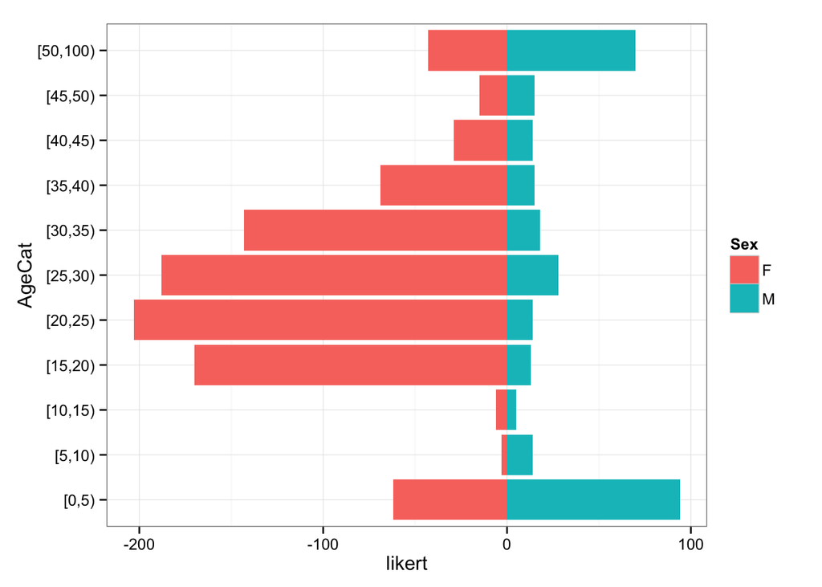

```r
Demographics <- referrals %>% select(GlobalRecordId, Sex, Age) %>%
  mutate(AgeCat = cut(Age,breaks=c(0,5,10,15,20,25,30,35,40,45,50,100),right = F)) %>%
  select(Sex, AgeCat) %>% group_by(AgeCat, Sex) %>%
  summarise(value=n()) %>%
  mutate(likert = ifelse(Sex=="M", value, -value))

Demographics <- na.omit(Demographics)

ggplot(data=Demographics, aes(y = likert, x = AgeCat, fill=Sex)) +
  geom_bar(data= filter(Demographics, Sex == "F"), stat = "identity", position="stack") +
  geom_bar(data=filter(Demographics, Sex == "M"), stat = "identity", position="stack") +
  theme_bw() +
  coord_flip()
```

```r
# qplot(Duration, ReferralDistance, data=referrals, colour=DepartureLevel)
#
# ggplot(referrals, aes(x=PatientLoc, y=Duration)) + geom_boxplot()
# ggplot(referrals, aes(x=PatientLoc, y=ReferralDistance)) + geom_boxplot()
#
#
# lm(ReferralDistance ~ PatientLoc, referrals)
# lm(Duration ~ PatientLoc, filter(referrals, DepartureisStation==T))
#
# facility <- referrals %>% select(Departure, PickUp, Arrival, CatchementPop, ReferralDistance) %>%
#     group_by(Departure)
```